# Neural Net Package Examples

Raphael Cobe

12/13/2017

```r
library("neuralnet")
```

Going to create a neural network to perform square rooting Type ?neuralnet for more information on the neuralnet library

Generate 50 random numbers uniformly distributed between 0 and 100 And store them as a dataframe

```r
traininginput <-  as.data.frame(runif(50, min=0, max=100))
trainingoutput <- sqrt(traininginput)
```

Column bind the data into one variable

```r
trainingdata <- cbind(traininginput,trainingoutput)
colnames(trainingdata) <- c("Input","Output")
```

```r
net.sqrt <- neuralnet(Output~Input,trainingdata, hidden=10, threshold=0.01)
print(net.sqrt)
```

```
## $call
## neuralnet(formula = Output ~ Input, data = trainingdata, hidden = 10,
##     threshold = 0.01)
##
## $response
##          Output
## 1  6.0965775786
## 2  3.2690044298
## 3  8.3513968922
## 4  7.8446405105
## 5  9.6226986051
## 6  3.5345927304
## 7  9.4795953268
## 8  2.8044990723
## 9  7.3970680872
```

[output cut: 383 more lines]

Plot the neural network

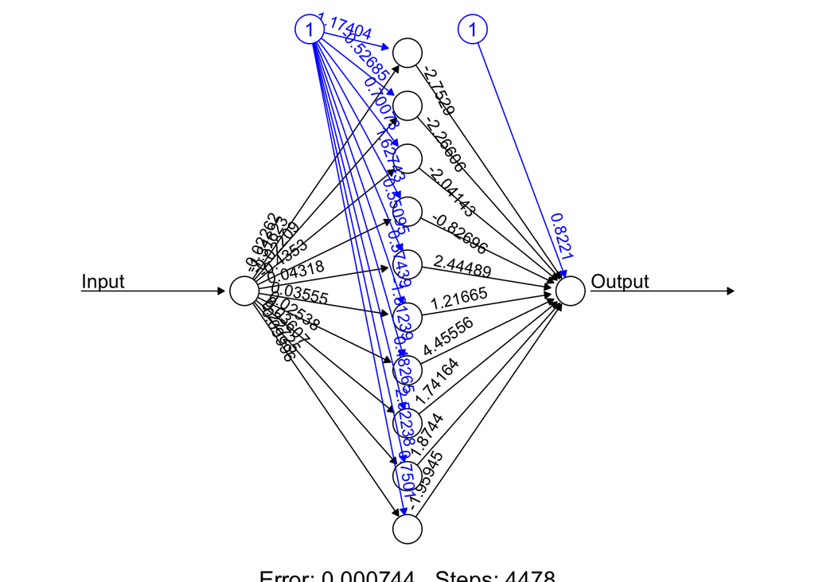

```r
plot(net.sqrt, rep = "best")
```

Test the neural network on some training data

```r
testdata <- as.data.frame((1:10)^2) #Generate some squared numbers
net.results <- compute(net.sqrt, testdata) #Run them through the neural network
```

Lets see what properties net.sqrt has

```r
ls(net.results)
```

```
## [1] "net.result" "neurons"
```

Lets see the results

```r
print(net.results$net.result)
```

```
##              [,1]
##  [1,] 1.000766494
##  [2,] 1.991579331
##  [3,] 3.010904096
##  [4,] 3.988678610
##  [5,] 5.000611372
##  [6,] 6.006291308
##  [7,] 6.996013649
##  [8,] 7.997945212
##  [9,] 9.007398424
## [10,] 9.971620029
```

Lets display a better version of the results

```r
cleanoutput <- cbind(testdata,sqrt(testdata),
                     as.data.frame(net.results$net.result))
colnames(cleanoutput) <- c("Input","Expected Output","Neural Net Output")
print(cleanoutput)
```

```
##    Input Expected Output Neural Net Output
## 1      1               1       1.000766494
## 2      4               2       1.991579331
## 3      9               3       3.010904096
## 4     16               4       3.988678610
## 5     25               5       5.000611372
## 6     36               6       6.006291308
## 7     49               7       6.996013649
## 8     64               8       7.997945212
## 9     81               9       9.007398424
## 10   100              10       9.971620029
```

# `sin` function

Generate random data and the dependent variable

```r
x <- sort(runif(50, min = 0, max = 4*pi))
y <- sin(x)

data <- cbind(x,y)
```

Create the neural network responsible for the sin function

```r
library(neuralnet)
sin.nn <- neuralnet(y ~ x, data = data, hidden = 5, stepmax = 100000, learningrate = 10e-6,
                    act.fct = 'logistic', err.fct = 'sse', rep = 5, lifesign = "minimal",
                    linear.output = T)
```

```
## hidden: 5    thresh: 0.01    rep: 1/5    steps: stepmax  min thresh: 0.01235383196
## hidden: 5    thresh: 0.01    rep: 2/5    steps:    7368  error: 0.13785  time: 0.93 secs
## hidden: 5    thresh: 0.01    rep: 3/5    steps: stepmax  min thresh: 0.01899256597
## hidden: 5    thresh: 0.01    rep: 4/5    steps:    3372  error: 0.08604  time: 0.41 secs
## hidden: 5    thresh: 0.01    rep: 5/5    steps: stepmax  min thresh: 0.01159848482
```

Visualize the neural network

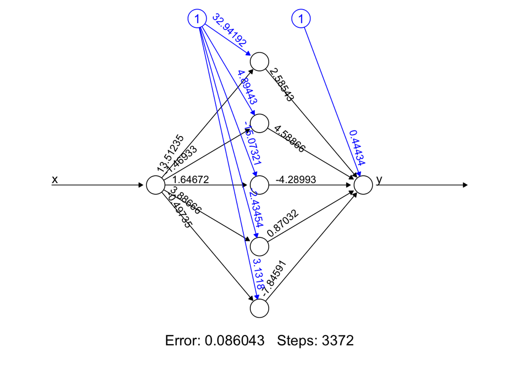

```r
plot(sin.nn, rep = "best")
```

Generate data for the prediction of the using the neural net;

```r
testdata<- as.data.frame(runif(10, min=0, max=(4*pi)))
testdata
```

```
##    runif(10, min = 0, max = (4 * pi))
## 1                       7.87611288982
## 2                       4.72214781431
## 3                       9.64061612762
## 4                       9.48118137589
## 5                       1.71017296777
## 6                       0.71062693989
## 7                       6.93553464371
## 8                       5.41102499228
## 9                       0.09203577515
## 10                      6.90280599467
```

Calculate the real value using the `sin` function

```r
testdata.result <- sin(testdata)
```

Make the prediction

```r
sin.nn.result <- compute(sin.nn, testdata)
sin.nn.result$net.result
```

```
##                [,1]
##  [1,]  1.0406076463
##  [2,] -0.9802533763
##  [3,] -0.2831259473
##  [4,] -0.1439931189
##  [5,]  0.9738662835
##  [6,]  0.6358466730
##  [7,]  0.6083245129
##  [8,] -0.7317624845
##  [9,]  0.2170414750
## [10,]  0.5799669476
```

Compare with the real values:

```r
better <- cbind(testdata, sin.nn.result$net.result, testdata.result, (sin.nn.result$net.result-testdata.result))
colnames(better) <- c("Input", "NN Result", "Result", "Error")

better
```

```
##            Input     NN Result         Result            Error
## 1  7.87611288982  1.0406076463  0.99975511375  0.0408525325022
## 2  4.72214781431 -0.9802533763 -0.99995238296  0.0196990066159
## 3  9.64061612762 -0.2831259473 -0.21416622249 -0.0689597247923
## 4  9.48118137589 -0.1439931189 -0.05637351342 -0.0876196055079
## 5  1.71017296777  0.9738662835  0.99030278928 -0.0164365057891
## 6  0.71062693989  0.6358466730  0.65230909020 -0.0164624171731
## 7  6.93553464371  0.6083245129  0.60705500264  0.0012695102242
## 8  5.41102499228 -0.7317624845 -0.76572018079  0.0339576962443
## 9  0.09203577515  0.2170414750  0.09190589737  0.1251355776649
## 10 6.90280599467  0.5799669476  0.58072640447 -0.0007594568319
```

Calculate the RMSE:

```r
library(Metrics)
rmse(better$Result, better$`NN Result`)
```

```
## [1] 0.05643138794
```

Plot the results:

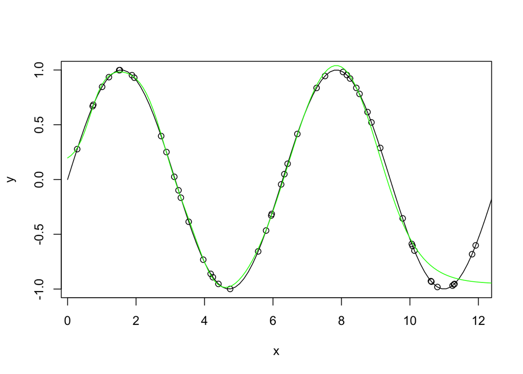

```r
plot(x,y)
plot(sin, 0, (4*pi), add=T)
x1 <- seq(0, 4*pi, by=0.1)
lines(x1, compute(sin.nn, data.frame(x=x1))$net.result, col="green")
```

# A classification problem

Using the `iris` dataset

```r
data(iris)
iris.dataset <- iris
```

Check what is inside the dataset:

```r
head(iris.dataset)
```

```
##   Sepal.Length Sepal.Width Petal.Length Petal.Width Species
## 1          5.1         3.5          1.4         0.2  setosa
## 2          4.9         3.0          1.4         0.2  setosa
## 3          4.7         3.2          1.3         0.2  setosa
## 4          4.6         3.1          1.5         0.2  setosa
## 5          5.0         3.6          1.4         0.2  setosa
## 6          5.4         3.9          1.7         0.4  setosa
```

Change the dataset so we are able to predict classes:

```r
iris.dataset$setosa <- iris.dataset$Species=="setosa"
iris.dataset$virginica = iris.dataset$Species == "virginica"
iris.dataset$versicolor = iris.dataset$Species == "versicolor"
```

Separate into train and test data:

```r
train <- sample(x = nrow(iris.dataset), size = nrow(iris)*0.5)
train
```

```
##  [1] 140  60  99 146  77  27  87 129  12  57  10 138  86   5  26  64 127
## [18]  14   7  59 124 141   1 126 128 143  62 105  75 123  49  71  55  32
## [35]  81 120  67  46  69 108   2 137  37  92 125  29  80  56 107  18 133
## [52] 121  68  50  25 145 144   8 109  58  16 139  13   3 148  36  84 149
## [69] 119 113  28 147  66  42  15
```

```r
iristrain <- iris.dataset[train,]
irisvalid <- iris.dataset[-train,]
print(nrow(iristrain))
```

```
## [1] 75
```

```r
print(nrow(irisvalid))
```

```
## [1] 75
```

Build the Neural Network for the classification:

```r
nn <- neuralnet(setosa+versicolor+virginica ~ Sepal.Length + Sepal.Width, data=iristrain, hidden=3,
                rep = 2, err.fct = "ce", linear.output = F, lifesign = "minimal", stepmax = 1000000)
```

```
## hidden: 3    thresh: 0.01    rep: 1/2    steps:  365909  error: 47.25669 time: 54.22 secs
## hidden: 3    thresh: 0.01    rep: 2/2    steps: stepmax  min thresh: 0.01056613581
```

Let’s check the neural network that we just built

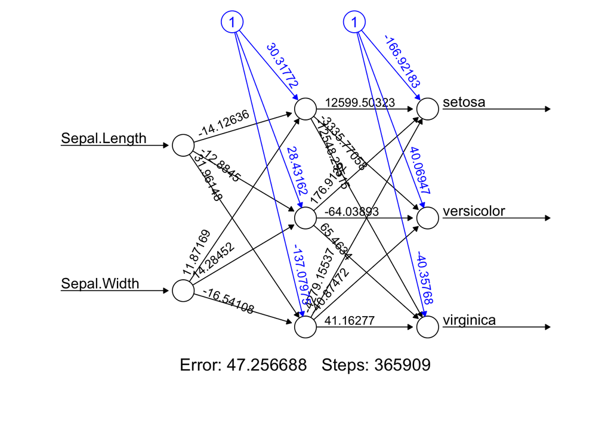

```r
plot(nn, rep="best")
```

Let’s try to make the prediction:

```r
comp <- compute(nn, irisvalid[-3:-8])
pred.weights <- comp$net.result
idx <- apply(pred.weights, 1, which.max)
pred <- c('setosa', 'versicolor', 'virginica')[idx]
table(pred, irisvalid$Species)
```

```
##
## pred         setosa versicolor virginica
##   setosa         25          0         0
##   versicolor      0         14         5
##   virginica       0         14        17
```

# AND operation

```r
AND <- c(rep(0,3),1)
OR <- c(0,rep(1,3))
binary.data <- data.frame(expand.grid(c(0,1), c(0,1)), AND)
print(net <- neuralnet(AND~Var1+Var2, binary.data, hidden=0, rep=10, err.fct="ce", linear.output=FALSE))
```

[output not shown]

[output cut: 341 more lines]

```
## reached.threshold   0.008273096262   0.00911007759   0.007824180974
## steps             122.000000000000 131.00000000000 147.000000000000
## Intercept.to.AND  -12.759376823468 -12.81500928926 -12.977999402273
## Var1.to.AND         8.395846010380   8.43717374812   8.530234448081
## Var2.to.AND         8.414423287111   8.48159841518   8.576142070168
##                                 10
## error               0.047312789084
## reached.threshold   0.009506137375
## steps             128.000000000000
## Intercept.to.AND  -12.453899042970
## Var1.to.AND         8.234146550304
## Var2.to.AND         8.179337885117
##
## attr(,"class")
## [1] "nn"
```

Now to validate the predictions:

```r
input <- data.frame(expand.grid(c(0,1), c(0,1)))
net.results <- compute(net, input)
cbind(round(net.results$net.result), AND)
```

```
##        AND
## [1,] 0   0
## [2,] 0   0
## [3,] 0   0
## [4,] 1   1
```